# Forecasting Total Supplier Services Using ARIMA and Prophet

## Introduction

This notebook explores the temporal trends in **total supplier services**, focusing on how service volumes evolve over time and across regions. The objective is to understand variations in supplier services, identify regions with significant growth or inefficiencies, and provide actionable insights through forecasting.

Two time-series models, **ARIMA** and **Prophet**, are employed to predict future service volumes, enabling a comprehensive understanding of regional service distribution over time.

## Models Used

### 1. ARIMA (AutoRegressive Integrated Moving Average)

- **Objective**: Model linear patterns and autocorrelation in service volumes.
- **Strengths**: Best suited for stationary data and capturing lagged dependencies.
- **Tuning**:
  - Multiple configurations tested for ARIMA parameters (p, d, q).
  - Final model selection based on AIC and BIC scores.

### 2. Prophet

- **Objective**: Capture non-linear trends and seasonality in service volumes.
- **Strengths**: Handles missing data, incorporates holidays and seasonality effects seamlessly.
- **Configuration**:
  - Yearly seasonality added for better long-term trend detection.
  - Default changepoint settings leveraged for trend flexibility.

## Methodology

### Data Preprocessing

- Time-series anomalies detected and removed using Isolation Forest and Local Outlier Factor (LOF) methods.
- Data reformatted for ARIMA and Prophet, ensuring compatibility (`ds` for dates and `y` for service volumes).

### Model Evaluation

- TimeSeriesSplit applied to validate model performance.
- Forecasting for the next 5 years conducted for the top regions.

## Research Question

**RQ4**: How have supplier charges varied by region over time, and how can these temporal trends help optimize costs?

## Outputs

### Forecast Visualizations

- Plots of **observed vs. forecasted** service volumes for ARIMA and Prophet models.
- Regional trends highlighting disparities and identifying regions of significant growth.

### Exported Predictions

- Forecasted service volumes saved for the top regions for the next 5 years.
- Outputs include confidence intervals for Prophet forecasts.

## Implications

- **High-growth regions** may require capacity planning and additional resources.
- Forecasts reveal regions with consistently low service volumes, guiding targeted interventions.
- Combining insights from both models enhances reliability for decision-making.

```python
# Set the working directory to the folder
import os
os.chdir('/Users/rozani/Desktop/capstone')
```

```python
#filter warnings
import warnings
warnings.filterwarnings("ignore")

# Import required modules
import numpy as np
import pandas as pd


from pmdarima.arima import auto_arima
import pmdarima as pm
from statsmodels.tsa.arima.model import ARIMA

from sklearn.model_selection import cross_validate
from sklearn.model_selection import TimeSeriesSplit
from sklearn.metrics import mean_squared_error, mean_absolute_error, mean_absolute_percentage_error

import matplotlib.pyplot as plt

#!pip install prophet
from prophet import Prophet
from prophet.diagnostics import cross_validation, performance_metrics
```

```python
# Load data
# data is loaded from a CSV file and parsed by the Year column
data = pd.read_csv('cleaned_data.csv', parse_dates=['Year'], index_col='Year')

test_data = pd.read_csv('test_data.csv', parse_dates=['Year'], index_col='Year')

# Combine training and test data by appending rows
combined_data = pd.concat([data, test_data])
```

# Check stationarity and variance

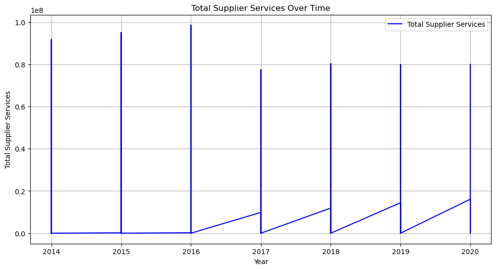

```python
# Plotting Average Supplier Charges Over Time
plt.figure(figsize=(12, 6))
plt.plot(data.index, data['Tot_Suplr_Srvcs'], label='Total Supplier Services', color='blue')
plt.xlabel('Year')
plt.ylabel('Total Supplier Services')
plt.title('Total Supplier Services Over Time')
plt.grid(True)
plt.legend()
plt.show()
```

[output not shown]

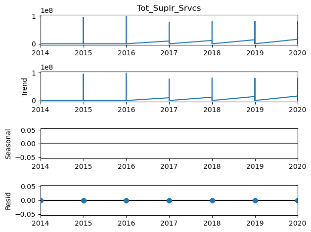

```python
from statsmodels.tsa.seasonal import seasonal_decompose

result = seasonal_decompose(data['Tot_Suplr_Srvcs'], model='additive', period=1)
result.plot()
plt.plot()
```

# Analysis of Total Supplier Services Over Time

## Hypothesis for ADF Test

The Augmented Dickey-Fuller (ADF) test is used to determine whether a time series is stationary or contains a unit root (non-stationary). The hypotheses for the ADF test are:

- **Null Hypothesis (H₀)**: The series has a unit root, meaning it is *non-stationary*.
- **Alternative Hypothesis (H₁)**: The series is *stationary* (i.e., it does not have a unit root).

The p-value obtained from the ADF test will help us determine whether to reject the null hypothesis.

```python
from statsmodels.tsa.stattools import adfuller

# Create a subset for the ADF test using data from the last 3 years
data_subset = data['Tot_Suplr_Srvcs']['2018':'2020']

# Run the ADF test on this subset
adf_result = adfuller(data_subset)
print("ADF Test p-value:", adf_result[1])
```

```
ADF Test p-value: 0.0
```

### Results

The p-value obtained from the Augmented Dickey-Fuller (ADF) test is 0.0, which is much smaller than the commonly used significance level of 0.05. As a result, we reject the null hypothesis and conclude that the time series is stationary

## Hypothesis for KPSS Test

- **Null Hypothesis (H₀)**: The series is stationary (trend-stationary).
- **Alternative Hypothesis (H₁)**: The series has a unit root and is non-stationary.

```python
from statsmodels.tsa.stattools import kpss

kpss_result = kpss(data['Tot_Suplr_Srvcs'])
print(kpss_result[1])
```

```
0.1
```

### Results

Since the p-value is greater than 0.05, we fail to reject the null hypothesis and conclude that the time series is stationary.

## Hypothesis for Phillips-Perron (PP) Test

The Phillips-Perron (PP) test is used to determine the stationarity of a time series by testing for a unit root. The hypotheses for the PP test are:

- **Null Hypothesis (H₀)**: The series has a unit root, meaning it is *non-stationary*.
- **Alternative Hypothesis (H₁)**: The series is *stationary* (i.e., it does not have a unit root).

```python
from arch import unitroot

pp_test = unitroot.PhillipsPerron(data['Tot_Suplr_Srvcs'])
print(pp_test)
```

```
     Phillips-Perron Test (Z-tau)
=====================================
Test Statistic               -722.088
P-value                         0.000
Lags                               88
-------------------------------------

Trend: Constant
Critical Values: -3.43 (1%), -2.86 (5%), -2.57 (10%)
Null Hypothesis: The process contains a unit root.
Alternative Hypothesis: The process is weakly stationary.
```

## Phillips-Perron Test Results for Total Supplier Services

### Test Summary

- **Test Statistic**: -722.088
- **P-value**: 0.000
- **Lags Used**: 88
- **Critical Values**:
  - 1%: -3.43
  - 5%: -2.86
  - 10%: -2.57

### Interpretation

1. **Null Hypothesis**:
   - The process contains a unit root (non-stationary).
2. **Alternative Hypothesis**:
   - The process is weakly stationary.
3. **Results**:
   - The test statistic (-722.088) is much smaller than the critical values at all levels.
   - The **p-value (0.000)** is below the significance threshold (e.g., 0.05).

### Conclusion

- The **null hypothesis is rejected**.
- The time series **does not contain a unit root**, meaning it is **stationary**.
- Stationarity indicates that the mean, variance, and autocovariance are constant over time, making the data suitable for time-series modeling without additional differencing.

# Plot auto-correlations

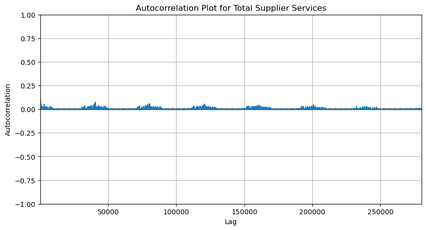

```python
from pandas.plotting import autocorrelation_plot


# Plot the autocorrelation
plt.figure(figsize=(10, 5))
autocorrelation_plot(data['Tot_Suplr_Srvcs'])
plt.title('Autocorrelation Plot for Total Supplier Services')
plt.xlabel('Lag')
plt.ylabel('Autocorrelation')
plt.grid(True)
plt.show()
```

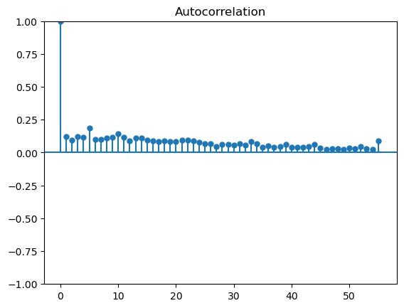

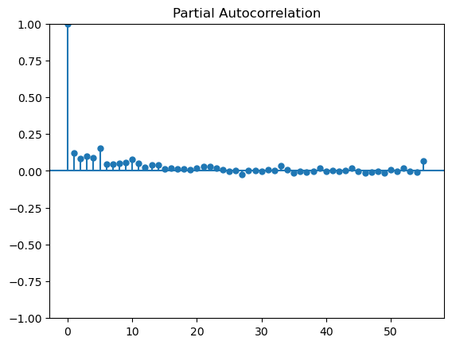

```python
from statsmodels.graphics.tsaplots import plot_acf, plot_pacf


plot_acf(data['Tot_Suplr_Srvcs'])
plt.show()

plot_pacf(data['Tot_Suplr_Srvcs'])
plt.show()
```